# Week 8: Bivariate linear regression

Tristan Muno

November 11, 2026

## Week 8 goals

By the end of today, you will be able to:

1. Frame a regression problem as **estimand** (what we want to know), **estimator** (the procedure) and **estimate** (the result we get).
2. Explain what OLS assumes, and see where the classical and the Bayesian account of the linear model meet.
3. Specify **weakly informative priors** for regression coefficients and defend them on principled grounds.
4. Understand `brms` as **sampling from the posterior**: an estimator that returns a distribution rather than one number.
5. Interpret `brms` output and extract **quantities of interest**, such as predictions and marginal effects.

## Today

1. **Recap:** estimand, estimator, estimate
2. **The question:** does democracy protect people from their own state?
3. **All eight steps, one model**, with a detour to 1801
4. **Three ways to an answer:** expected values, predicted values, marginal effects
5. **Checking the assumptions** of the model we just fitted

## Where today fits

Today we walk **all eight steps** on one real model, for the first time since week 1.

Table 1: The 8-step Bayesian workflow. Every homework exercises the steps introduced so far, cumulatively, and the exam runs all eight end to end.

| # | Step | What you produce |
| --- | --- | --- |
| 1 | **Estimand** | The quantity you want to learn about, stated precisely as a target before any model is fitted. |
| 2 | **Data summary** | The data described: measurement, coverage, obvious issues. |
| 3 | **Formal model** | Likelihood and priors written down, the generative model. |
| 4 | **Prior predictive check** | Simulate from the priors, confirm they imply plausible data. |
| 5 | **Fit** | Estimate with `brms`, weakly-informative priors by default. |
| 6a | **MCMC diagnostics** | R-hat, ESS, divergences, trace plots. Did sampling work? |
| 6b | **Posterior predictive check** | Does the fitted model reproduce key features of the data? |
| 7 | **Interpretation** | Answer the estimand on the outcome scale, with uncertainty. |
| 8 | **Limitations** | What the analysis can and cannot support, threats and next steps. |

# Recap

## Estimand, estimator, estimate

The three words from week 1, now filled in for today.

Table 2: The three terms of statistical inference, with today’s model filled in.

| Term | Question it answers | Today |
| --- | --- | --- |
| **Estimand** | What do we want to learn? | How physical integrity differs between countries that differ in democracy, the slope $\beta$ |
| **Estimator** | How do we learn it from data? | Bayes’ theorem, computed by MCMC in `brms` (week 7) |
| **Estimate** | What do we get? | A posterior distribution for $\beta$, not one number |

**Note**

**The estimate is a distribution.** Every number we report today is a summary of that distribution, and it comes with its uncertainty.

# The question

## Do democracies repress less?

> Do more democratic states respect the physical integrity of their citizens more?

Why we might expect it:

- **Accountability:** leaders who kill or torture can be voted out.
- **Constraints:** courts, a free press and a parliament make repression costly.
- **Norms:** democracies settle conflict by voting and bargaining, not by force.

Political scientists call this the **domestic democratic peace** (Davenport 2007).

## The data

V-Dem, year 2019, **179 countries** (Coppedge et al. 2026). Two expert-coded indices, both rescaled to run from 0 to 100:

- **Electoral democracy:** free and fair elections, suffrage, freedom of expression and association.
- **Physical integrity:** freedom from political killing and torture by the state. Higher means more respect.

**View source**

```r
vdem |>
  filter(
    country %in%
      c(
        "Denmark",
        "Germany",
        "Hungary",
        "Mexico",
        "India",
        "Russia",
        "China",
        "Saudi Arabia"
      )
  ) |>
  arrange(desc(democracy)) |>
  select(Country = country, Democracy = democracy, Integrity = integrity) |>
  knitr::kable()
```

Table 3: Eight countries from the data, ordered by their democracy score.

| Country | Democracy | Integrity |
| --- | --- | --- |
| Denmark | 91.6 | 97.0 |
| Germany | 87.8 | 97.4 |
| Mexico | 68.4 | 49.7 |
| Hungary | 46.6 | 95.8 |
| India | 43.0 | 56.7 |
| Russia | 25.9 | 34.7 |
| China | 7.5 | 42.9 |
| Saudi Arabia | 1.5 | 20.9 |

# All eight steps

## Step 1: Estimand

The research question:

> What is the association between democracy and physical integrity?

What precisely do we want to learn?

> How much higher, on average, is physical integrity in countries whose democracy score is one point higher?

That is a **slope**, and we call it $\beta$.

**Warning**

**An association is not a causal effect.** Nobody assigns countries their regime, and democracy and repression can shape each other. We compare different countries, we do not watch one country democratise.

## Step 2: One variable at a time

**View source**

```r
vdem |>
  pivot_longer(
    c(democracy, integrity),
    names_to = "variable",
    values_to = "value"
  ) |>
  mutate(
    variable = case_match(
      variable,
      "democracy" ~ "Electoral democracy",
      "integrity" ~ "Physical integrity"
    )
  ) |>
  ggplot(aes(x = value)) +
  geom_histogram(
    binwidth = 5,
    boundary = 0,
    fill = col_1,
    colour = "white"
  ) +
  facet_wrap(~variable) +
  theme_classic() +
  labs(x = "Score (0 to 100)", y = "Countries", title = "One variable at a time")
```

[figure not shown]

Figure 1: The two variables one at a time, one bar per bin of five points. Democracy is spread across the whole scale. Physical integrity piles up just below its ceiling of 100.

## Step 2: Both at once

**View source**

```r
ggplot(vdem, aes(x = democracy, y = integrity)) +
  geom_point(colour = col_1, alpha = 0.7, size = 2) +
  scale_x_continuous(limits = c(0, 100)) +
  scale_y_continuous(limits = c(0, 100)) +
  theme_classic() +
  labs(
    x = "Electoral democracy",
    y = "Physical integrity",
    title = "Look before you fit"
  )
```

[figure not shown]

Figure 2: Physical integrity against electoral democracy, one point per country in 2019. The cloud rises from left to right, and it is much wider among autocracies than among democracies.

## Step 3: Formal model

**1. Outcome distribution.** Integrity is drawn from a normal distribution with mean $\mu_i$ and standard deviation $\sigma$:

$$y_i \sim \mathcal{N}(\mu_i, \sigma)
\tag{1}$$

**2. Linear predictor.** The mean is a straight line in democracy:

$$\mu_i = \alpha + \beta x_i
\tag{2}$$

- $y_i$ is the physical integrity of country $i$, the **outcome**, or **dependent variable**.
- $x_i$ is the democracy score of country $i$, the **predictor**, or **independent variable**.
- $\alpha$ is the **intercept**, the expected integrity of a country with democracy 0, and $\beta$ is the **slope**, our estimand.
- $\sigma$ is the **residual standard deviation**: how far, typically, countries lie from the line.

Read $\sim$ as **is drawn from** (random) and $=$ as **is defined as** (fixed): all the randomness sits in the first line.

Where does the idea of a line plus normally distributed errors come from?

# A detour to 1801

## The same model, written classically

Equation 1 and Equation 2 say exactly the same thing as

$$y_i = \alpha + \beta x_i + \varepsilon_i, \qquad \varepsilon_i \sim \mathcal{N}(0, \sigma)
\tag{3}$$

- The **error term** $\varepsilon_i$ is the distance between $y_i$ and the true line, which we never observe.
- A **residual** is the distance between $y_i$ and a *fitted* line, which we can compute, so it is how we look at the errors.

Where do the errors come from? Everything the democracy score does not capture: conflict, history, wealth, and measurement error.

This is how Gauss wrote it, more than 200 years ago.

## A lost planet

- **1 January 1801:** in Palermo, Giuseppe Piazzi spots a faint moving point of light, the dwarf planet **Ceres**.
- He follows it for about six weeks, then it disappears into the glare of the Sun.
- Astronomers hold a handful of positions, each a little off, and must predict where Ceres will reappear months later.
- **Carl Friedrich Gauss**, aged 24, uses **all** the observations at once. He picks the orbit that makes the **squared residuals**, the squared distances between observed and predicted positions, as small as possible.
- On the last night of 1801, Ceres is found again, close to where Gauss said it would be (Stigler 1986; Gauss 1809).

**Note**

**Every measurement contains a little error.** Gauss assumed these errors were normally distributed, which is exactly our $\varepsilon_i$ in Equation 3.

## Our residuals

**View source**

```r
vdem |>
  mutate(fitted = fitted(ls_fit)) |>
  ggplot(aes(x = democracy, y = integrity)) +
  geom_segment(
    aes(xend = democracy, yend = fitted),
    colour = col_3,
    alpha = 0.5
  ) +
  geom_abline(
    intercept = ls_alpha,
    slope = ls_beta,
    colour = col_2,
    linewidth = 1.2
  ) +
  geom_point(colour = col_1, size = 1.6) +
  theme_classic() +
  labs(
    x = "Electoral democracy",
    y = "Physical integrity",
    title = "One line, 179 residuals"
  )
```

[figure not shown]

Figure 3: The least-squares line through our data. Each purple segment is one country’s residual: the vertical distance between the observed integrity and the line.

## The least-squares line

Add up the squared residuals:

$$\text{SSR}(\alpha, \beta) = \sum_{i=1}^{n} (y_i - \alpha - \beta x_i)^2
\tag{4}$$

The **least-squares line** is the one pair $(\alpha, \beta)$ that makes Equation 4 as small as possible.

Squaring makes a large residual count far more than a small one, and positive and negative residuals cannot cancel.

**View source**

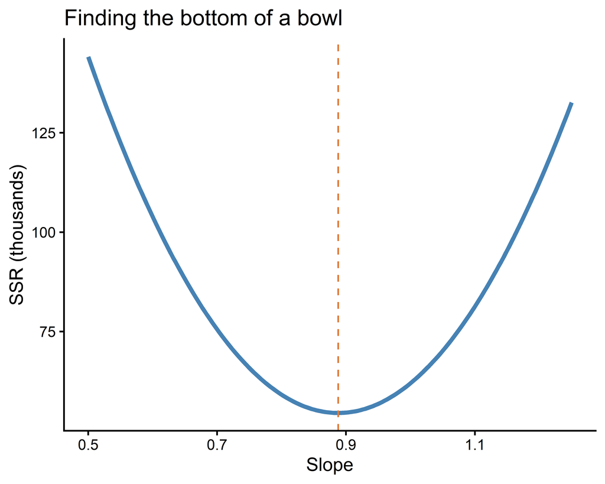

Figure 4: The sum of squared residuals for different slopes, with the intercept held at its least-squares value. The bowl has one lowest point, the least-squares slope.

```r
tibble(beta = seq(0.5, 1.25, length.out = 200)) |>
  mutate(
    ssr = map_dbl(
      beta,
      \(b) sum((vdem$integrity - ls_alpha - b * vdem$democracy)^2)
    )
  ) |>
  ggplot(aes(x = beta, y = ssr / 1000)) +
  geom_line(colour = col_1, linewidth = 1.2) +
  geom_vline(xintercept = ls_beta, colour = col_2, linetype = "dashed") +
  theme_classic() +
  labs(
    x = "Slope",
    y = "SSR (thousands)",
    title = "Finding the bottom of a bowl"
  )
```

## Sneak preview: when is that line the best?

The least-squares line is the **best linear unbiased estimator** when these conditions hold:

Table 4: Six assumptions behind the least-squares line.

|  | Assumption | In short |
| --- | --- | --- |
| A1 | Linearity | The average of $y$ really is a straight line in $x$. |
| A2 | Exogeneity | The error terms are unrelated to $x$. |
| A3 | Homoscedasticity | The error terms have the same variance for every $x$. |
| A4 | No perfect collinearity | The predictor actually varies. |
| A5 | Independence | One country’s error term tells us nothing about another’s. |
| A6 | Normality | The error terms are normally distributed. |

A1 to A5 are the **Gauss-Markov assumptions**, A6 is our Equation 1, and we check all six after step 8.

## Back to our model: the likelihood

Equation 1 and Equation 2, applied to all $n$ countries at once, give the **likelihood**:

$$\mathcal{L}(\alpha, \beta, \sigma \mid \mathbf{y}, \mathbf{x}) = \prod_{i=1}^{n} \frac{1}{\sigma\sqrt{2\pi}} \exp\left(-\frac{(y_i - \alpha - \beta x_i)^2}{2\sigma^2}\right)
\tag{5}$$

Look inside the exponent: it holds the **squared residual** of Equation 4. The smaller the residuals, the larger the likelihood.

**Note**

**The normal likelihood already contains Gauss’s criterion.** The line with the smallest squared residuals is also the line that makes the data most likely. The full derivation is in the appendix.

**Gauss stops here: one best line.** Bayes adds priors and keeps every plausible line.

# What Bayes adds

## Step 3: The posterior

**3. Posterior, proportional form.**

$$P(\alpha, \beta, \sigma \mid \mathbf{y}, \mathbf{x}) \propto \mathcal{L}(\alpha, \beta, \sigma \mid \mathbf{y}, \mathbf{x}) \times P(\alpha) \, P(\beta) \, P(\sigma)
\tag{6}$$

- $\mathbf{y}$ is the whole integrity column and $\mathbf{x}$ the whole democracy column, 179 entries each.
- The likelihood $\mathcal{L}$ is Equation 5, the part Gauss already knew.

The left side lists every unknown: **three parameters, so three priors** to choose.

**Standard deviation or variance?**

**Note**

**The second number in $\mathcal{N}(\mu, \sigma)$ is a standard deviation.** This is the convention of this course and of `brms`. The variance is its square, $\sigma^2$, and it appears only where a formula needs it.

## Step 3: The complete model

Equation 6 told us we need **three priors**, one per unknown. With them, the whole model fits on one card:

$$\begin{aligned}
y_i &\sim \mathcal{N}(\mu_i, \sigma) && \text{outcome distribution} \\
\mu_i &= \alpha + \beta x_i && \text{linear predictor} \\
\alpha &\sim \mathcal{N}(50, 20) && \text{prior} \\
\beta &\sim \mathcal{N}(0, 0.5) && \text{prior} \\
\sigma &\sim \text{Exponential}(0.05) && \text{prior}
\end{aligned}
\tag{7}$$

**How to read the prior on the intercept**

**Note**

**The prior on $\alpha$ in words.** A full autocracy (democracy 0) could sit anywhere on the integrity scale, so the prior is centred mid-scale. With 95 percent probability it lies between 10 and 90.

**How to read the prior on the slope**

**Note**

**The prior on $\beta$ in words.** Centred on no association, because the sign is what we want to learn. A slope of 1 would carry a country across the whole integrity scale as it moves from full autocracy to full democracy. The prior allows that, with 95 percent of its mass between $-1$ and $+1$, but little beyond.

**How to read the prior on the residual standard deviation**

**Note**

**The prior on $\sigma$ in words.** A standard deviation must be positive. An exponential with rate 0.05 has a mean of $1 / 0.05 = 20$ points, so countries typically lie a fifth of the scale from the line, and smaller standard deviations are more plausible than larger ones.

**Tip**

**This card is step 3, for every model in this course.** Later models change the outcome distribution and add a link line, the rest stays.

## Step 3: The priors, drawn

**View source**

```r
bind_rows(
  tibble(
    parameter = "alpha: the intercept",
    value = seq(-30, 130, length.out = 300),
    density = dnorm(value, mean = 50, sd = 20)
  ),
  tibble(
    parameter = "beta: the slope",
    value = seq(-2, 2, length.out = 300),
    density = dnorm(value, mean = 0, sd = 0.5)
  ),
  tibble(
    parameter = "sigma: the residual standard deviation",
    value = seq(0, 100, length.out = 300),
    density = dexp(value, rate = 0.05)
  )
) |>
  ggplot(aes(x = value, y = density)) +
  geom_line(colour = col_3, linewidth = 1) +
  facet_wrap(~parameter, scales = "free") +
  theme_classic() +
  labs(
    x = "Value",
    y = "Density",
    title = "What we believe before seeing any country"
  )
```

[figure not shown]

Figure 5: The three priors as curves. Each says how plausible each value of that parameter is before we look at a single country.

## From one line to many

Gauss asks: **which single line** fits best?

We ask: **which lines are plausible**, and how plausible is each?

- Bayes’ theorem combines the likelihood (Equation 5) with the priors of Equation 7.
- MCMC (week 7) then **draws** thousands of lines, one per draw of $(\alpha, \beta, \sigma)$.
- Lines that fit the data better turn up **more often**, because the chain spends more time where the posterior is high.

**Important**

**We do not fit one line.** We simulate a whole collection of lines, and how often a line appears is how plausible it is.

## A model that generates data

Read Equation 7 as a **recipe**: choose $\alpha$, $\beta$ and $\sigma$, and the model produces a whole dataset.

**View source**

```r
set.seed(2026)
worlds <- tribble(
  ~world , ~alpha , ~beta , ~sigma ,
  "A: alpha 25, beta 0.9, sigma 18" , 25 , 0.9 , 18 ,
  "B: alpha 70, beta 0, sigma 15" , 70 , 0 , 15 ,
  "C: alpha 95, beta -0.5, sigma 5" , 95 , -0.5 , 5
)

made_up <- expand_grid(worlds, democracy = vdem$democracy) |>
  mutate(integrity = rnorm(n(), alpha + beta * democracy, sigma)) |>
  select(world, democracy, integrity)

bind_rows(
  vdem |> transmute(world = "Observed", democracy, integrity),
  made_up
) |>
  mutate(world = fct_inorder(world)) |>
  ggplot(aes(x = democracy, y = integrity)) +
  geom_point(colour = col_1, alpha = 0.6, size = 1) +
  facet_wrap(~world, nrow = 1) +
  theme_classic() +
  labs(
    x = "Electoral democracy",
    y = "Physical integrity",
    title = "One real world, three made-up ones"
  )
```

[figure not shown]

Figure 6: The observed data and three datasets made up by the model, each from one fixed choice of the three parameters and the observed democracy scores. A generative model can produce data, and comparing its data with ours is how we check it.

## Step 4: Prior predictive check

What lines do our priors consider possible?

**View source**

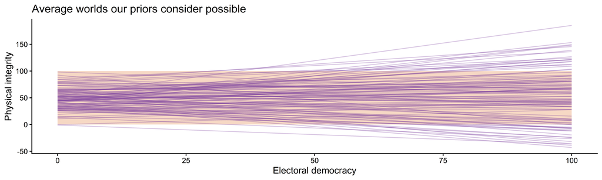

Figure 7: One hundred lines drawn from the priors alone. The shaded band is the 0 to 100 range the integrity index can take. Lines leaving the band describe impossible worlds.

```r
set.seed(2026)
tibble(
  draw = 1:100,
  alpha = rnorm(100, mean = 50, sd = 20),
  beta = rnorm(100, mean = 0, sd = 0.5)
) |>
  expand_grid(democracy = c(0, 100)) |>
  mutate(integrity = alpha + beta * democracy) |>
  ggplot(aes(x = democracy, y = integrity, group = draw)) +
  annotate(
    "rect",
    xmin = 0,
    xmax = 100,
    ymin = 0,
    ymax = 100,
    fill = col_2,
    alpha = 0.3
  ) +
  geom_line(colour = col_3, alpha = 0.3) +
  theme_classic() +
  labs(
    x = "Electoral democracy",
    y = "Physical integrity",
    title = "Average worlds our priors consider possible"
  )
```

Of 10,000 prior lines, **64 percent** stay inside the scale from end to end.

## Step 4: Whole worlds from the priors

Draw $\alpha$, $\beta$ and $\sigma$ from the priors, then run the recipe.

**View source**

```r
set.seed(8)
tibble(
  world = paste("Prior draw", 1:3),
  alpha = rnorm(3, mean = 50, sd = 20),
  beta = rnorm(3, mean = 0, sd = 0.5),
  sigma = rexp(3, rate = 0.05)
) |>
  expand_grid(democracy = vdem$democracy) |>
  mutate(integrity = rnorm(n(), alpha + beta * democracy, sigma)) |>
  ggplot(aes(x = democracy, y = integrity)) +
  geom_hline(yintercept = c(0, 100), linetype = "dashed", colour = "grey50") +
  geom_point(colour = col_3, alpha = 0.6, size = 1) +
  facet_wrap(~world, nrow = 1) +
  theme_classic() +
  labs(
    x = "Electoral democracy",
    y = "Physical integrity",
    title = "Datasets our priors consider possible"
  )
```

[figure not shown]

Figure 8: Three datasets generated by the model with parameters drawn from the priors. The dashed lines mark the ends of the scale, so points beyond them are values no country can have.

## Step 5: Fit the model

```r
week08_priors <- c(
  prior(normal(50, 20), class = "b", coef = "Intercept"),
  prior(normal(0, 0.5), class = "b", coef = "democracy"),
  prior(exponential(0.05), class = "sigma")
)

fit <- brm(
  integrity ~ 0 + Intercept + democracy,
  data = vdem,
  family = gaussian(),
  prior = week08_priors,
  chains = 4,
  iter = 2000,
  seed = 2026,
  refresh = 0,
  file = here("website", "slides", "data", "week08-fit"),
  file_refit = "on_change"
)
```

Four chains of 1,000 draws after warm-up give **4,000 draws** of $(\alpha, \beta, \sigma)$. That is 4,000 plausible lines.

## Step 6a: MCMC diagnostics

**View source**

```r
mcmc_plot(fit, type = "trace") +
  scale_colour_manual(values = chain_cols) +
  theme_classic()
```

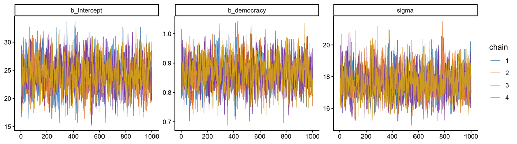

Figure 9: Trace plots for the three parameters, four chains each. The chains overlap and wander around the same region, so the plots show no sign of non-convergence.

Largest R-hat 1.002, smallest ESS 1764, 0 divergent transitions. **No evidence of non-convergence.**

## Step 6b: Posterior predictive check

The generative model once more, now with parameters drawn from the **posterior**.

**View source**

```r
set.seed(2026)
pp_check(fit, ndraws = 50) +
  geom_vline(xintercept = 100, linetype = "dashed", colour = "grey50") +
  theme_classic() +
  labs(
    x = "Physical integrity",
    title = "Observed integrity against what the model generates"
  )
```

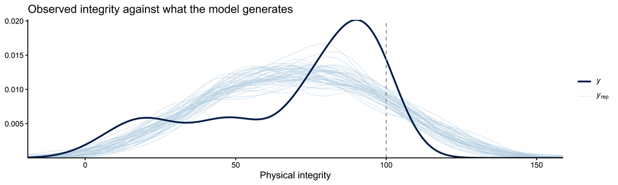

Figure 10: Posterior predictive check. The dark line is the observed distribution of physical integrity, the pale lines are datasets generated by the fitted model. The model spills past the ceiling of 100 and fails to reproduce the pile-up just below it.

# Step 7: Three ways to an answer

## Three questions, three quantities

Table 5: Three quantities of interest from one fitted model, each answering a different substantive question.

| Quantity | The question it answers | From | Uncertainty about |
| --- | --- | --- | --- |
| **Expected value** | What integrity do we expect, on average, for countries with democracy $x$? | `posterior_epred()` | $\alpha$ and $\beta$: **estimation** (systematic) uncertainty |
| **Predicted value** | Where would one new country with democracy $x$ fall? | `posterior_predict()` | $\alpha$, $\beta$ and $\sigma$: estimation plus **fundamental** (stochastic) uncertainty |
| **Marginal effect** | How much does expected integrity change if democracy is one point higher? | the posterior of $\beta$ | $\beta$: **estimation** (systematic) uncertainty |

**Tip**

**Report all three, every time.** Each answers a different question, and together they show both the pattern and how much single countries vary around it.

## Expected values

**View source**

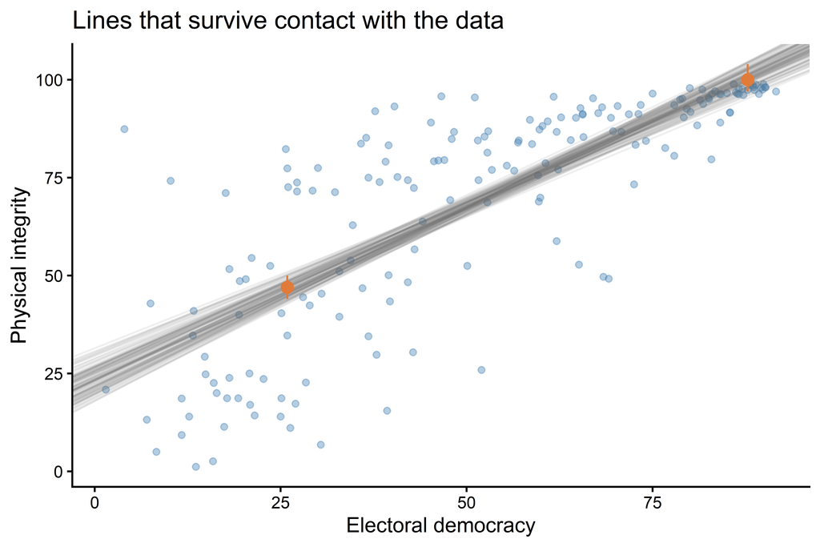

Figure 11: One hundred posterior lines over the data. The orange intervals are the expected integrity, with 90 percent credible intervals, at the democracy scores of Russia and Germany.

```r
set.seed(2026)
posterior_lines <- as_draws_df(fit) |>
  as_tibble() |>
  slice_sample(n = 100)

expected_points <- tibble(
  democracy = c(x_low, x_high),
  low = c(ep_low[1], ep_high[1]),
  mid = c(ep_low[2], ep_high[2]),
  high = c(ep_low[3], ep_high[3])
)

ggplot(vdem, aes(x = democracy, y = integrity)) +
  geom_point(colour = col_1, alpha = 0.4, size = 1.4) +
  geom_abline(
    data = posterior_lines,
    aes(intercept = b_Intercept, slope = b_democracy),
    colour = "grey40",
    alpha = 0.1
  ) +
  geom_pointrange(
    data = expected_points,
    aes(x = democracy, y = mid, ymin = low, ymax = high),
    colour = col_2,
    inherit.aes = FALSE
  ) +
  theme_classic() +
  labs(
    x = "Electoral democracy",
    y = "Physical integrity",
    title = "Lines that survive contact with the data"
  )
```

A country with **Russia’s** democracy score (25.9): expected integrity **47**, 90 percent credible interval 44 to 50.

A country with **Germany’s** score (87.8): expected integrity **100**, from 97 to 104.

These are **averages** over many countries with that score. Their intervals carry only **estimation uncertainty**: we do not know $\alpha$ and $\beta$ exactly.

## Predicted values

**View source**

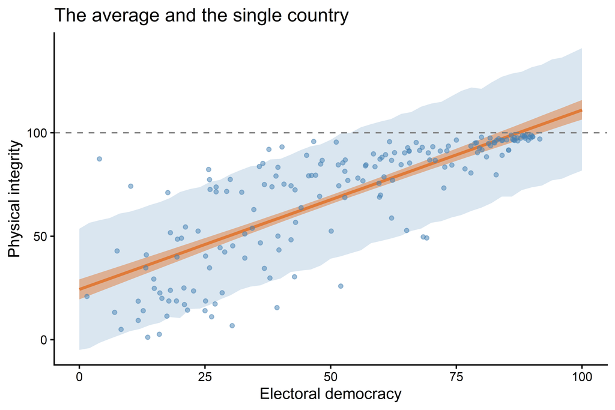

Figure 12: Expected values (narrow band) and predicted values (wide band), both 90 percent intervals. The wide band adds the residual standard deviation, so it shows where single countries fall. The dashed line marks the ceiling of the scale.

```r
ggplot(bands, aes(x = democracy)) +
  geom_ribbon(aes(ymin = pr_lo, ymax = pr_hi), fill = col_1, alpha = 0.2) +
  geom_ribbon(aes(ymin = ep_lo, ymax = ep_hi), fill = col_2, alpha = 0.5) +
  geom_line(aes(y = mid), colour = col_2, linewidth = 1) +
  geom_point(
    data = vdem,
    aes(y = integrity),
    colour = col_1,
    alpha = 0.5,
    size = 1.2
  ) +
  geom_hline(yintercept = 100, linetype = "dashed", colour = "grey50") +
  theme_classic() +
  labs(
    x = "Electoral democracy",
    y = "Physical integrity",
    title = "The average and the single country"
  )
```

One new country with **Russia’s** score: predicted integrity from **18 to 76** (90 percent). Russia itself has 34.7.

One new country with **Germany’s** score: from **71 to 130**.

These intervals add **fundamental uncertainty**: countries differ even at the same democracy score.

**52 percent** of those predictions lie above 100, a value no country can have.

## Marginal effect

**View source**

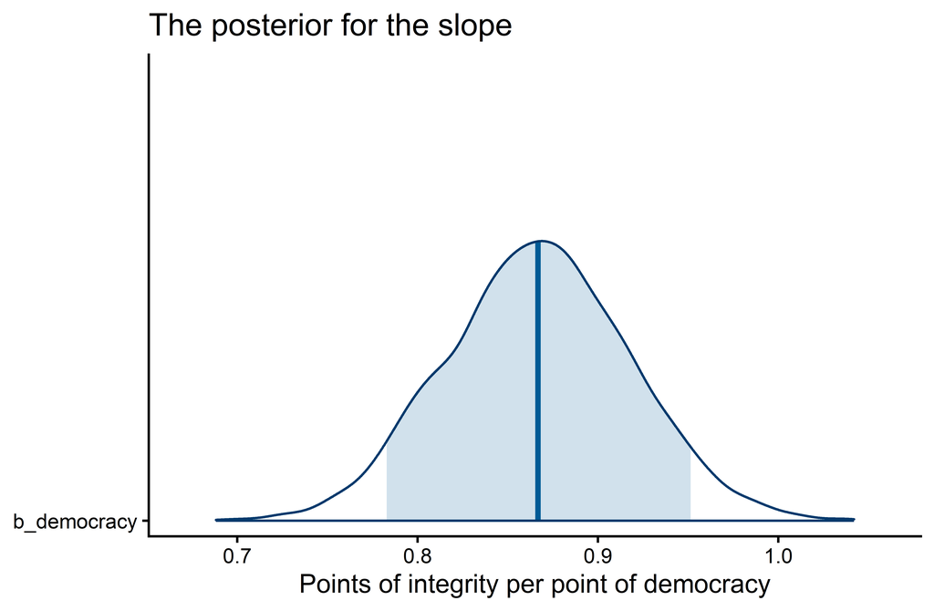

Figure 13: The posterior of the slope, our estimand from step 1. The shaded area is the 90 percent credible interval.

```r
mcmc_plot(fit, variable = "b_democracy", type = "areas", prob = 0.9) +
  theme_classic() +
  labs(
    x = "Points of integrity per point of democracy",
    y = NULL,
    title = "The posterior for the slope"
  )
```

A one point increase in democracy is, on average, associated with a **0.87 point** increase in physical integrity, with 90 percent probability that the value lies in [0.78, 0.95].

**100 percent** of the posterior lies above zero.

## Step 8: Limitations

- **One year, many countries:** this compares countries in 2019, it does not show what happens when a country democratises.
- **Association, not effect:** repression silences elections too, and civil conflict lowers both scores.
- **Measured with error:** both indices are themselves estimates from expert ratings.
- **A scale with a ceiling:** the normal likelihood predicts impossible values above 100 (steps 6b and 7).

**Note**

**Models are always wrong, but some are useful.** Naming what this model cannot do is part of the answer, not an apology for it.

# Checking the assumptions of our model

## Six assumptions, one model

Back to the sneak preview. The assumptions protect two different things:

- **The line itself:** if A1 or A2 fails, the line points in the wrong place, and more data will not fix it.
- **The uncertainty around the line:** if A3, A5 or A6 fails, the line can be fine but our intervals are too wide or too narrow.

For each assumption we ask:

1. **What it says**, in words and as a formula
2. **Why it matters**: what goes wrong if it fails
3. **Why this check**: what in the data could reveal a violation
4. **Your verdict**, then mine

## A1: Linearity

**View source**

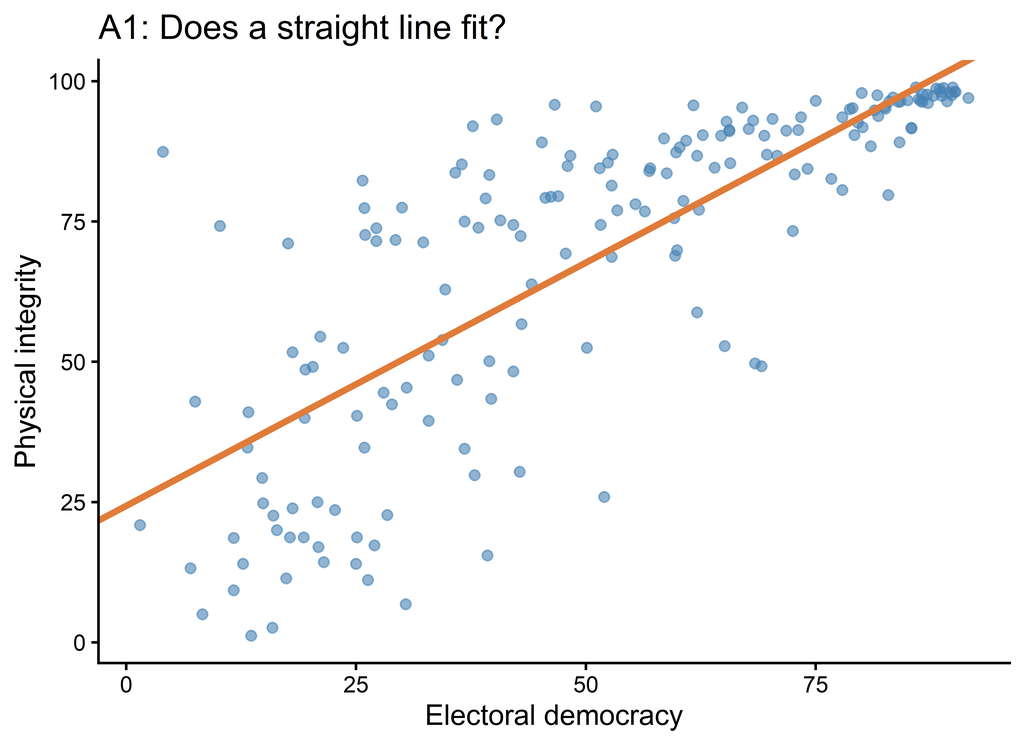

Figure 14: The data with the posterior mean line of our model. If the average of integrity follows a straight line, the points scatter around the line without a systematic bend.

```r
ggplot(vdem, aes(x = democracy, y = integrity)) +
  geom_point(colour = col_1, alpha = 0.6, size = 1.6) +
  geom_abline(
    intercept = fixef(fit)["Intercept", "Estimate"],
    slope = fixef(fit)["democracy", "Estimate"],
    colour = col_2,
    linewidth = 1.2
  ) +
  theme_classic() +
  labs(
    x = "Electoral democracy",
    y = "Physical integrity",
    title = "A1: Does a straight line fit?"
  )
```

**What it says.** The average of $y$ is a straight line in $x$: $E(y_i \mid x_i) = \alpha + \beta x_i$.

**Why it matters.** If the true average bends, a straight line is wrong about the shape, and $\beta$ averages over slopes that differ along the scale.

**Why this check.** Linearity is a claim about $y$ against $x$, so we look at exactly that: the data and the fitted line.

**Roughly holds**, with a slight hump in the middle, the “more murder in the middle” pattern (Fein 1995).

## A2: Exogeneity

**What it says.** The error terms are unrelated to the predictor: $E(\varepsilon_i \mid x_i) = 0$.

**Why it matters.** If something in $\varepsilon_i$ also moves $x$, the line credits democracy with that something’s effect, and $\beta$ is biased.

**Why there is no check.** The fitted line makes the residuals uncorrelated with $x$ by construction, so the data can never reveal a violation. We have to argue instead: what hides in our $\varepsilon_i$? Civil conflict, threats to the regime, wealth, colonial history, and each of them plausibly moves **democracy** as well.

**Important**

**No check in the data can confirm A2, and no prior can repair it.** It is a question of research design, which is why it belongs to steps 1 and 8.

## A3: Homoscedasticity

**View source**

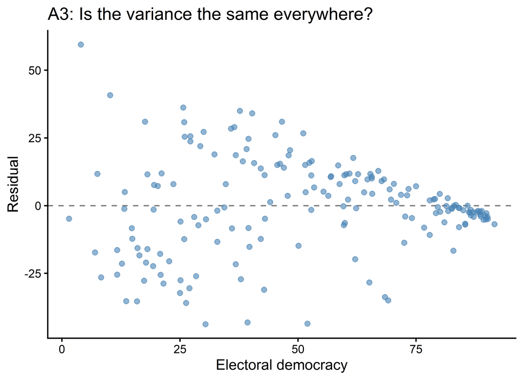

Figure 15: Residuals against democracy. With a constant variance the cloud would be a band of even height. It narrows sharply from left to right.

```r
ggplot(model_resid, aes(x = democracy, y = residual)) +
  geom_hline(yintercept = 0, linetype = "dashed", colour = "grey50") +
  geom_point(colour = col_1, alpha = 0.6, size = 1.6) +
  theme_classic() +
  labs(
    x = "Electoral democracy",
    y = "Residual",
    title = "A3: Is the variance the same everywhere?"
  )
```

**What it says.** The error terms have the same variance for every $x$: $\operatorname{Var}(\varepsilon_i \mid x_i) = \sigma^2$.

**Why it matters.** Our model has one $\sigma$ for all countries. If the true variation differs, predicted intervals are too wide in one place and too narrow in another.

**Why this check.** Residuals take the line away, so what is left is the variation around it, and a change in its width becomes visible.

**Violated:** the residual standard deviation is 23 points below democracy 50, and 4 points above 75.

## A4: No perfect collinearity

**What it says.** The predictor actually varies, and with several predictors, no predictor is an exact copy of the others.

**Why it matters.** If every country had the same democracy score, the data could not tell us anything about a slope.

**Why this check.** We look at the range of the predictor.

It runs from 1.5 to 91.6: **holds, trivially.**

## A5: Independence

**View source**

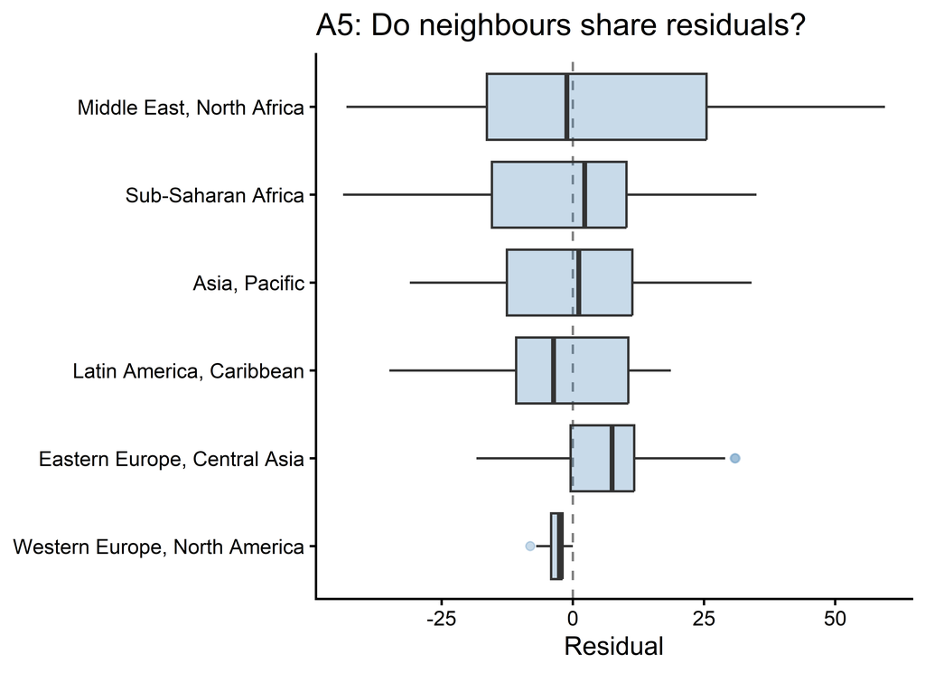

Figure 16: Residuals by world region. With independent error terms every region would centre on zero with a similar width. Regions differ in both.

```r
model_resid |>
  mutate(region = fct_reorder(region, residual, .fun = sd)) |>
  ggplot(aes(x = residual, y = region)) +
  geom_vline(xintercept = 0, linetype = "dashed", colour = "grey50") +
  geom_boxplot(fill = col_1, alpha = 0.3, outlier.colour = col_1) +
  theme_classic() +
  labs(
    x = "Residual",
    y = NULL,
    title = "A5: Do neighbours share residuals?"
  )
```

**What it says.** One country’s error term tells us nothing about another’s.

**Why it matters.** The likelihood multiplies one term per country, as if each were new information. If neighbours move together, we have less information than we count, and our intervals are too narrow.

**Why this check.** Countries in one region share history and shocks, so if residuals cluster anywhere, they cluster by region.

**Doubtful:** regions differ in their typical residual and in how widely their residuals vary.

## A6: Normality

**View source**

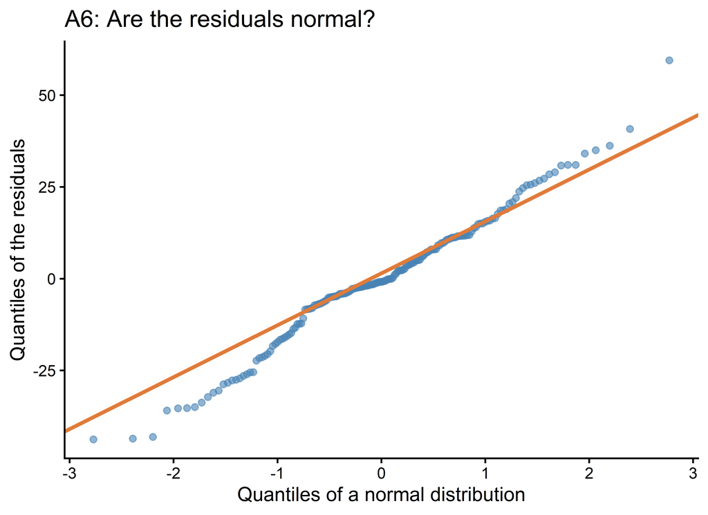

Figure 17: Quantile-quantile plot of the residuals. Normally distributed residuals would lie on the orange line. Points bending away at the ends mean the tails are not normal.

```r
ggplot(model_resid, aes(sample = residual)) +
  stat_qq(colour = col_1, alpha = 0.6) +
  stat_qq_line(colour = col_2, linewidth = 1) +
  theme_classic() +
  labs(
    x = "Quantiles of a normal distribution",
    y = "Quantiles of the residuals",
    title = "A6: Are the residuals normal?"
  )
```

**What it says.** The error terms are normally distributed, which is our outcome distribution, Equation 1.

**Why it matters.** The normal distribution decides how often large deviations happen, so it shapes every predicted value.

**Why this check.** A Q-Q plot lines up the sorted residuals against what a normal distribution would give, so any departure shows as a bend.

**Violated in the tails:** both ends bend away, the large residuals of the autocracies from A3.

## The verdicts

Table 6: The six assumptions checked on today’s model.

[output not shown]

**Important**

**Bayesian estimation does not make assumptions disappear.** It writes them into the model, where we can see them, check them and change them.

# Wrap-up

## Learning goals: achieved?

Table 7: The week 8 learning goals, each with its key answer and the part of the session that covers it.

| # | Learning goal | Key answer | Where |
| --- | --- | --- | --- |
| 1 | Frame a regression as estimand, estimator, estimate | The slope $\beta$, Bayes plus MCMC, a posterior distribution | Recap |
| 2 | What OLS assumes, and where it meets Bayes | Least squares minimises squared residuals, which the normal likelihood contains. Six assumptions, checked on our model | Gauss, Assumptions |
| 3 | Weakly informative priors, defended | Each prior argued on the 0 to 100 scale and checked by simulating from it | The model card, Step 4 |
| 4 | `brms` samples from the posterior | 4,000 draws are 4,000 plausible lines, better lines appear more often | One line to many |
| 5 | Quantities of interest | Expected values, predicted values and the marginal effect, all three every time | Step 7 |

## Homework

- `hw-08`: the whole workflow on a second question from the same V-Dem data, due 18 November. Linked from the Schedule.
- A sample solution is published after the due date.

**Important**

**Individual feedback is only available through the opt-in path.** To opt in, add an open-source `license.md` to your submission repo **and** mark your finished homework with a commit whose message is `final submission`.

## References

Coppedge, Michael, John Gerring, Carl Henrik Knutsen, Staffan I. Lindberg, Jan Teorell, et al. 2026. *V-Dem Country-Year Dataset V16*. Varieties of Democracy (V-Dem) Project. https://v-dem.net/data/the-v-dem-dataset/.

Davenport, Christian. 2007. *State Repression and the Domestic Democratic Peace*. Cambridge University Press.

Fein, Helen. 1995. “More Murder in the Middle: Life-Integrity Violations and Democracy in the World, 1987.” *Human Rights Quarterly* 17 (1): 170–91.

Gauss, Carl Friedrich. 1809. *Theoria Motus Corporum Coelestium in Sectionibus Conicis Solem Ambientium*. Perthes und Besser.

Stigler, Stephen M. 1986. *The History of Statistics: The Measurement of Uncertainty Before 1900*. Harvard University Press.

# Appendix

## Appendix A: least squares is maximum likelihood

Take the logarithm of Equation 5. Products become sums, and the logarithm does not move the maximum:

$$\ell(\alpha, \beta, \sigma) = -n \log\left(\sigma\sqrt{2\pi}\right) - \frac{1}{2\sigma^2} \sum_{i=1}^{n} (y_i - \alpha - \beta x_i)^2
\tag{8}$$

The first term does not contain $\alpha$ or $\beta$. In the second, $\frac{1}{2\sigma^2}$ is a positive constant with respect to $\alpha$ and $\beta$, and it carries a minus sign. So making $\ell$ as large as possible means making the sum as small as possible:

$$\arg\max_{\alpha, \beta} \, \ell(\alpha, \beta, \sigma) = \arg\min_{\alpha, \beta} \sum_{i=1}^{n} (y_i - \alpha - \beta x_i)^2 = \arg\min_{\alpha, \beta} \, \text{SSR}(\alpha, \beta)
\tag{9}$$

The maximum likelihood line under normally distributed errors is the least-squares line of Equation 4.

## Appendix A: the closed form

Setting the derivatives of Equation 4 with respect to $\alpha$ and $\beta$ to zero and solving gives

$$\hat{\beta} = \frac{\sum_{i=1}^{n} (x_i - \bar{x})(y_i - \bar{y})}{\sum_{i=1}^{n} (x_i - \bar{x})^2} = \frac{\operatorname{Cov}(\mathbf{x}, \mathbf{y})}{\operatorname{Var}(\mathbf{x})}, \qquad \hat{\alpha} = \bar{y} - \hat{\beta} \bar{x}
\tag{10}$$

For our data: $\hat{\beta} =$ 0.888 and $\hat{\alpha} =$ 23.11. The posterior medians are 0.867 and 24.3. With 179 countries and weakly informative priors, the likelihood dominates, so the two nearly coincide. The difference is in what comes with them: one pair of numbers, or a whole distribution of lines.

## Appendix B: the likelihood surface

**View source**

```r
sigma_ls <- sigma(ls_fit)

expand_grid(
  alpha = seq(ls_alpha - 12, ls_alpha + 12, length.out = 80),
  beta = seq(ls_beta - 0.2, ls_beta + 0.2, length.out = 80)
) |>
  mutate(
    log_lik = map2_dbl(
      alpha,
      beta,
      \(a, b) {
        sum(dnorm(
          vdem$integrity,
          mean = a + b * vdem$democracy,
          sd = sigma_ls,
          log = TRUE
        ))
      }
    )
  ) |>
  ggplot(aes(x = beta, y = alpha, fill = log_lik)) +
  geom_raster() +
  scale_fill_viridis_c(option = "magma", name = "Log-\nlikelihood") +
  annotate(
    "point",
    x = ls_beta,
    y = ls_alpha,
    colour = "white",
    shape = 4,
    size = 4,
    stroke = 2
  ) +
  theme_classic() +
  labs(x = "Slope", y = "Intercept", title = "The most likely line is the least-squares line")
```

[figure not shown]

Figure 18: The log-likelihood over intercept and slope, with sigma fixed at its least-squares value. Brighter is more likely. The cross marks the least-squares estimate, which sits at the top of the surface.